# S_van_Mesdag_Biodiversity_C+H_1

Savanna van Mesdag

2023-10-11

## R Markdown

##The following is written by Savanna van Mesdag, going through the relevant coding and analyses for the biodiversity analyses for the Warton slag bank and Hodbarrow.

#setwd#

#To run the following code to carry out the analyses, the following packages must be installed#

```r
install.packages("iNEXT", repos =   "http://chao.stat.nthu.edu.tw/wordpress/software_download/")
install.packages('devtools', repos = "https://github.com/r-lib/devtools")
install.packages('AnneChao/iNEXT', repos =  "http://chao.stat.nthu.edu.tw/wordpress/software_download/")
install.packages("ggthemes", repos = "https://github.com/jrnold/ggthemes")
install.packages("vegan", repos = " https://github.com/vegandevs/vegan")
```

##The packages also need to be loaded prior to running the analyses and producing graphs#

```r
library(devtools)
```

```r
library(iNEXT)
library(ggplot2)
library(ggthemes)
library(vegan)
```

#Hodbarrow Data#

#Loading the Hodbarrow data#

```r
urlfile1 <- 'https://raw.githubusercontent.com/Savannankvm/Biodiversity-analyses-for-Warton-and-Hodbarrow/PhD-files/Hodbarrow_Abundance_Data.csv'

Hodbarrow_Nos <-read.csv(urlfile1)

print(Hodbarrow_Nos)
```

```
##     Quadrat_1 Quadrat_2 Quadrat_3 Quadrat_4 Quadrat_5 Quadrat_6 Quadrat_7
## 1           0         0         0         0         0         0         0
## 2           0         0         0         0         0         0         0
## 3           0         0         0         0         0         0         0
## 4           0         0         0         0         0         0         0
## 5           0         0         0         0         0         0         0
## 6           0         0         0         7         0         0         0
## 7           0        70       189         0         0         0         0
## 8           0         0         0         0         0         0         0
## 9           0         0         0         0         0         0         0
## 10          0         0         0         0         0         0         0
## 11          0         0         0         0         0         0         0
## 12          0         0         1         0         0         0         0
## 13          0         0         0         0         0         0         0
## 14          0         0         0         0         0         0         0
```

[output cut: 129 more lines]

#colSums to establish sample size for each of the quadrats.

```r
colSums(Hodbarrow_Nos)
```

```
## Quadrat_1 Quadrat_2 Quadrat_3 Quadrat_4 Quadrat_5 Quadrat_6 Quadrat_7
##       213       396       617       577       433       106       216
```

#Setting m to sample size for Quadrat 1. This will give me observed #qD value that will be most representative for Quadrat and Community. Will do the same #for the other communities below.

```r
m <- c(213)

Hodbarrow_Datam <- iNEXT(Hodbarrow_Nos, q=c(0), datatype= "abundance", size = m)

Hodbarrow_Datam
```

```
## Compare 7 assemblages with Hill number order q = 0.
## $class: iNEXT
##
## $DataInfo: basic data information
##   Assemblage   n S.obs     SC f1 f2 f3 f4 f5 f6 f7 f8 f9 f10
## 1  Quadrat_1 213     6 1.0000  0  3  0  0  0  0  0  0  0   1
## 2  Quadrat_2 396     7 1.0000  0  1  0  1  1  0  0  0  0   0
## 3  Quadrat_3 617    10 0.9951  3  1  0  1  0  0  0  0  0   0
## 4  Quadrat_4 577    15 0.9965  2  1  1  1  1  0  1  0  0   1
## 5  Quadrat_5 433    18 0.9954  2  2  2  0  1  1  0  0  0   0
## 6  Quadrat_6 106     7 0.9909  1  2  0  0  0  1  1  0  0   1
## 7  Quadrat_7 216    14 0.9908  2  2  0  0  0  1  1  0  0   2
##
## $iNextEst: diversity estimates with rarefied and extrapolated samples.
## $size_based (LCL and UCL are obtained for fixed size.)
```

[output cut: 130 more lines]

```r
n <- c(396)

Hodbarrow_Datan <- iNEXT(Hodbarrow_Nos, q=c(0), datatype= "abundance", size = n)

Hodbarrow_Datan
```

```
## Compare 7 assemblages with Hill number order q = 0.
## $class: iNEXT
##
## $DataInfo: basic data information
##   Assemblage   n S.obs     SC f1 f2 f3 f4 f5 f6 f7 f8 f9 f10
## 1  Quadrat_1 213     6 1.0000  0  3  0  0  0  0  0  0  0   1
## 2  Quadrat_2 396     7 1.0000  0  1  0  1  1  0  0  0  0   0
## 3  Quadrat_3 617    10 0.9951  3  1  0  1  0  0  0  0  0   0
## 4  Quadrat_4 577    15 0.9965  2  1  1  1  1  0  1  0  0   1
## 5  Quadrat_5 433    18 0.9954  2  2  2  0  1  1  0  0  0   0
## 6  Quadrat_6 106     7 0.9909  1  2  0  0  0  1  1  0  0   1
## 7  Quadrat_7 216    14 0.9908  2  2  0  0  0  1  1  0  0   2
##
## $iNextEst: diversity estimates with rarefied and extrapolated samples.
## $size_based (LCL and UCL are obtained for fixed size.)
```

[output cut: 129 more lines]

```r
o <- c(617)

Hodbarrow_Datao <- iNEXT(Hodbarrow_Nos, q=c(0), datatype= "abundance", size = o)

Hodbarrow_Datao
```

```
## Compare 7 assemblages with Hill number order q = 0.
## $class: iNEXT
##
## $DataInfo: basic data information
##   Assemblage   n S.obs     SC f1 f2 f3 f4 f5 f6 f7 f8 f9 f10
## 1  Quadrat_1 213     6 1.0000  0  3  0  0  0  0  0  0  0   1
## 2  Quadrat_2 396     7 1.0000  0  1  0  1  1  0  0  0  0   0
## 3  Quadrat_3 617    10 0.9951  3  1  0  1  0  0  0  0  0   0
## 4  Quadrat_4 577    15 0.9965  2  1  1  1  1  0  1  0  0   1
## 5  Quadrat_5 433    18 0.9954  2  2  2  0  1  1  0  0  0   0
## 6  Quadrat_6 106     7 0.9909  1  2  0  0  0  1  1  0  0   1
## 7  Quadrat_7 216    14 0.9908  2  2  0  0  0  1  1  0  0   2
##
## $iNextEst: diversity estimates with rarefied and extrapolated samples.
## $size_based (LCL and UCL are obtained for fixed size.)
```

[output cut: 126 more lines]

```r
p <- c(577)

Hodbarrow_Datap <- iNEXT(Hodbarrow_Nos, q=c(0), datatype= "abundance", size = p)

Hodbarrow_Datap
```

```
## Compare 7 assemblages with Hill number order q = 0.
## $class: iNEXT
##
## $DataInfo: basic data information
##   Assemblage   n S.obs     SC f1 f2 f3 f4 f5 f6 f7 f8 f9 f10
## 1  Quadrat_1 213     6 1.0000  0  3  0  0  0  0  0  0  0   1
## 2  Quadrat_2 396     7 1.0000  0  1  0  1  1  0  0  0  0   0
## 3  Quadrat_3 617    10 0.9951  3  1  0  1  0  0  0  0  0   0
## 4  Quadrat_4 577    15 0.9965  2  1  1  1  1  0  1  0  0   1
## 5  Quadrat_5 433    18 0.9954  2  2  2  0  1  1  0  0  0   0
## 6  Quadrat_6 106     7 0.9909  1  2  0  0  0  1  1  0  0   1
## 7  Quadrat_7 216    14 0.9908  2  2  0  0  0  1  1  0  0   2
##
## $iNextEst: diversity estimates with rarefied and extrapolated samples.
## $size_based (LCL and UCL are obtained for fixed size.)
```

[output cut: 126 more lines]

```r
q <- c(433)

Hodbarrow_Dataq <- iNEXT(Hodbarrow_Nos, q=c(0), datatype= "abundance", size = q)

Hodbarrow_Dataq
```

```
## Compare 7 assemblages with Hill number order q = 0.
## $class: iNEXT
##
## $DataInfo: basic data information
##   Assemblage   n S.obs     SC f1 f2 f3 f4 f5 f6 f7 f8 f9 f10
## 1  Quadrat_1 213     6 1.0000  0  3  0  0  0  0  0  0  0   1
## 2  Quadrat_2 396     7 1.0000  0  1  0  1  1  0  0  0  0   0
## 3  Quadrat_3 617    10 0.9951  3  1  0  1  0  0  0  0  0   0
## 4  Quadrat_4 577    15 0.9965  2  1  1  1  1  0  1  0  0   1
## 5  Quadrat_5 433    18 0.9954  2  2  2  0  1  1  0  0  0   0
## 6  Quadrat_6 106     7 0.9909  1  2  0  0  0  1  1  0  0   1
## 7  Quadrat_7 216    14 0.9908  2  2  0  0  0  1  1  0  0   2
##
## $iNextEst: diversity estimates with rarefied and extrapolated samples.
## $size_based (LCL and UCL are obtained for fixed size.)
```

[output cut: 126 more lines]

```r
r <- c(106)

Hodbarrow_Datar <- iNEXT(Hodbarrow_Nos, q=c(0), datatype= "abundance", size = r)

Hodbarrow_Datar
```

```
## Compare 7 assemblages with Hill number order q = 0.
## $class: iNEXT
##
## $DataInfo: basic data information
##   Assemblage   n S.obs     SC f1 f2 f3 f4 f5 f6 f7 f8 f9 f10
## 1  Quadrat_1 213     6 1.0000  0  3  0  0  0  0  0  0  0   1
## 2  Quadrat_2 396     7 1.0000  0  1  0  1  1  0  0  0  0   0
## 3  Quadrat_3 617    10 0.9951  3  1  0  1  0  0  0  0  0   0
## 4  Quadrat_4 577    15 0.9965  2  1  1  1  1  0  1  0  0   1
## 5  Quadrat_5 433    18 0.9954  2  2  2  0  1  1  0  0  0   0
## 6  Quadrat_6 106     7 0.9909  1  2  0  0  0  1  1  0  0   1
## 7  Quadrat_7 216    14 0.9908  2  2  0  0  0  1  1  0  0   2
##
## $iNextEst: diversity estimates with rarefied and extrapolated samples.
## $size_based (LCL and UCL are obtained for fixed size.)
```

[output cut: 128 more lines]

```r
s <- c(216)

Hodbarrow_Datas <- iNEXT(Hodbarrow_Nos, q=c(0), datatype= "abundance", size = s)

Hodbarrow_Datas
```

```
## Compare 7 assemblages with Hill number order q = 0.
## $class: iNEXT
##
## $DataInfo: basic data information
##   Assemblage   n S.obs     SC f1 f2 f3 f4 f5 f6 f7 f8 f9 f10
## 1  Quadrat_1 213     6 1.0000  0  3  0  0  0  0  0  0  0   1
## 2  Quadrat_2 396     7 1.0000  0  1  0  1  1  0  0  0  0   0
## 3  Quadrat_3 617    10 0.9951  3  1  0  1  0  0  0  0  0   0
## 4  Quadrat_4 577    15 0.9965  2  1  1  1  1  0  1  0  0   1
## 5  Quadrat_5 433    18 0.9954  2  2  2  0  1  1  0  0  0   0
## 6  Quadrat_6 106     7 0.9909  1  2  0  0  0  1  1  0  0   1
## 7  Quadrat_7 216    14 0.9908  2  2  0  0  0  1  1  0  0   2
##
## $iNextEst: diversity estimates with rarefied and extrapolated samples.
## $size_based (LCL and UCL are obtained for fixed size.)
```

[output cut: 127 more lines]

#Now to run the analysis again without specificying the size, can do this for #looking at the other diversity indices

```r
Hodbarrow_Data <- iNEXT(Hodbarrow_Nos, q=c(0), datatype= "abundance")

print(Hodbarrow_Data)
```

```
## Compare 7 assemblages with Hill number order q = 0.
## $class: iNEXT
##
## $DataInfo: basic data information
##   Assemblage   n S.obs     SC f1 f2 f3 f4 f5 f6 f7 f8 f9 f10
## 1  Quadrat_1 213     6 1.0000  0  3  0  0  0  0  0  0  0   1
## 2  Quadrat_2 396     7 1.0000  0  1  0  1  1  0  0  0  0   0
## 3  Quadrat_3 617    10 0.9951  3  1  0  1  0  0  0  0  0   0
## 4  Quadrat_4 577    15 0.9965  2  1  1  1  1  0  1  0  0   1
## 5  Quadrat_5 433    18 0.9954  2  2  2  0  1  1  0  0  0   0
## 6  Quadrat_6 106     7 0.9909  1  2  0  0  0  1  1  0  0   1
## 7  Quadrat_7 216    14 0.9908  2  2  0  0  0  1  1  0  0   2
##
## $iNextEst: diversity estimates with rarefied and extrapolated samples.
## $size_based (LCL and UCL are obtained for fixed size.)
```

[output cut: 198 more lines]

#Running further analyses to obtain additional biodiversity indices, including sample coverage#

```r
Hodbarrow2 <- estimateD(Hodbarrow_Nos, q = c(0,1,2), datatype = "abundance", base="coverage")
Hodbarrow2
```

```
##    Assemblage         m        Method Order.q        SC        qD    qD.LCL
## 1   Quadrat_1  193.2463   Rarefaction       0 0.9975081  5.975376  4.353247
## 2   Quadrat_1  193.2463   Rarefaction       1 0.9975081  2.349177  2.008298
## 3   Quadrat_1  193.2463   Rarefaction       2 0.9975081  1.827118  1.587406
## 4   Quadrat_2  252.7154   Rarefaction       0 0.9975081  6.847050  5.960194
## 5   Quadrat_2  252.7154   Rarefaction       1 0.9975081  3.526803  3.230030
## 6   Quadrat_2  252.7154   Rarefaction       2 0.9975081  2.731753  2.459093
## 7   Quadrat_3 1234.0000 Extrapolation       0 0.9975081 12.187737  5.662402
## 8   Quadrat_3 1234.0000 Extrapolation       1 0.9975081  4.323037  4.020444
## 9   Quadrat_3 1234.0000 Extrapolation       2 0.9975081  3.497420  3.248530
## 10  Quadrat_4  766.2629 Extrapolation       0 0.9975081 15.558731 10.242826
## 11  Quadrat_4  766.2629 Extrapolation       1 0.9975081  7.270478  6.835323
## 12  Quadrat_4  766.2629 Extrapolation       2 0.9975081  5.778112  5.372501
## 13  Quadrat_5  565.6096 Extrapolation       0 0.9975081 18.456957 13.598232
## 14  Quadrat_5  565.6096 Extrapolation       1 0.9975081 11.157573 10.406869
```

[output cut: 29 more lines]

#Running vegan analyses for Hodbarrow, to obtain species evenness indices

```r
R1 <- diversity(Hodbarrow_Nos$Quadrat_1)

Revenness1 <- R1/log(specnumber(Hodbarrow_Nos$Quadrat_1))

summary(Revenness1)
```

```
##    Min. 1st Qu.  Median    Mean 3rd Qu.    Max.
##  0.4775  0.4775  0.4775  0.4775  0.4775  0.4775
```

```r
R2 <- diversity(Hodbarrow_Nos$Quadrat_2)

Revenness2 <- R2/log(specnumber(Hodbarrow_Nos$Quadrat_2))

summary(Revenness2)
```

```
##    Min. 1st Qu.  Median    Mean 3rd Qu.    Max.
##  0.6502  0.6502  0.6502  0.6502  0.6502  0.6502
```

```r
R3 <- diversity(Hodbarrow_Nos$Quadrat_3)

Revenness3 <- R3/log(specnumber(Hodbarrow_Nos$Quadrat_3))

summary(Revenness3)
```

```
##    Min. 1st Qu.  Median    Mean 3rd Qu.    Max.
##  0.6329  0.6329  0.6329  0.6329  0.6329  0.6329
```

```r
R4 <- diversity(Hodbarrow_Nos$Quadrat_4)

Revenness4 <- R4/log(specnumber(Hodbarrow_Nos$Quadrat_4))

summary(Revenness4)
```

```
##    Min. 1st Qu.  Median    Mean 3rd Qu.    Max.
##  0.7311  0.7311  0.7311  0.7311  0.7311  0.7311
```

```r
R5 <- diversity(Hodbarrow_Nos$Quadrat_5)

Revenness5 <- R5/log(specnumber(Hodbarrow_Nos$Quadrat_5))

summary(Revenness5)
```

```
##    Min. 1st Qu.  Median    Mean 3rd Qu.    Max.
##  0.8324  0.8324  0.8324  0.8324  0.8324  0.8324
```

```r
R6 <- diversity(Hodbarrow_Nos$Quadrat_6)

Revenness6 <- R6/log(specnumber(Hodbarrow_Nos$Quadrat_6))

summary(Revenness6)
```

```
##    Min. 1st Qu.  Median    Mean 3rd Qu.    Max.
##  0.5058  0.5058  0.5058  0.5058  0.5058  0.5058
```

```r
R7 <- diversity(Hodbarrow_Nos$Quadrat_7)

Revenness7 <- R7/log(specnumber(Hodbarrow_Nos$Quadrat_7))

summary(Revenness7)
```

```
##    Min. 1st Qu.  Median    Mean 3rd Qu.    Max.
##   0.847   0.847   0.847   0.847   0.847   0.847
```

#Now for some data visualisation for the Hodbarrow data, including species curves graphs#

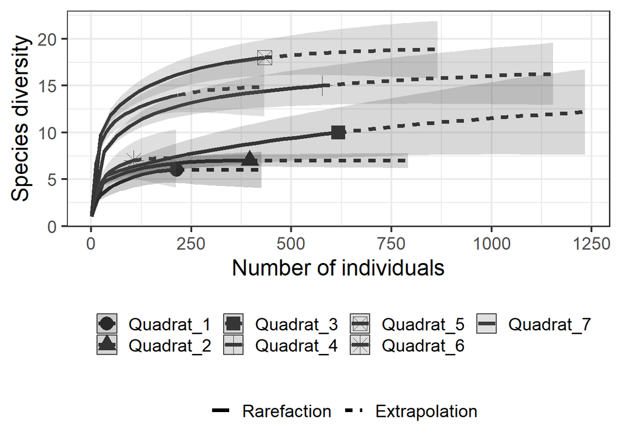

```r
Hodbarrow_Data_Graph1 <- ggiNEXT(x = Hodbarrow_Data, se=TRUE,
                                 facet.var= "None", grey=TRUE)
Hodbarrow_Data_Graph1
```

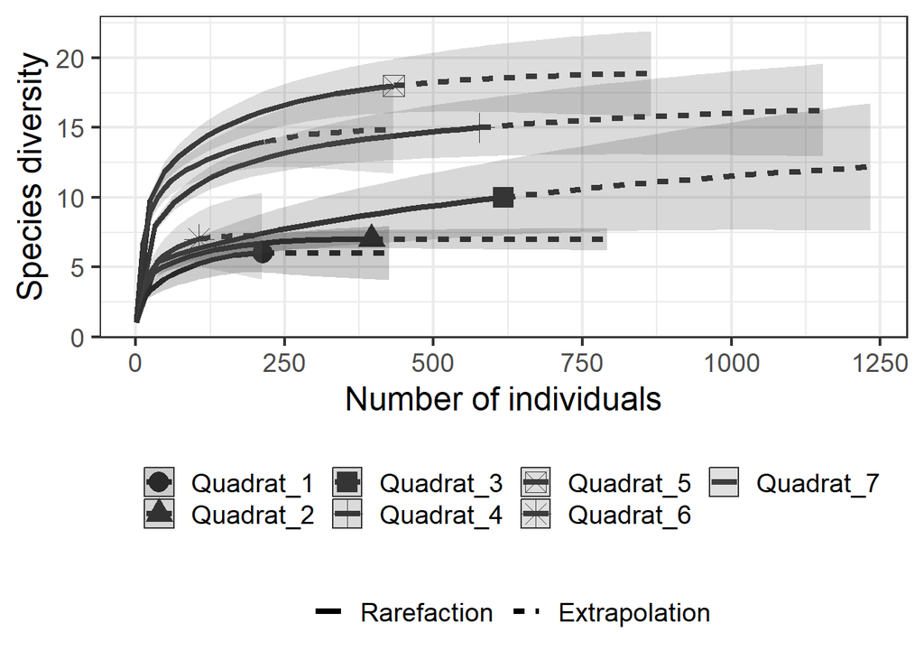

```r
Hodbarrow_Data_Graph2 <- ggiNEXT(x = Hodbarrow_Data, se=TRUE, type = 1,
                                 facet.var= "None", grey=TRUE)
Hodbarrow_Data_Graph2
```

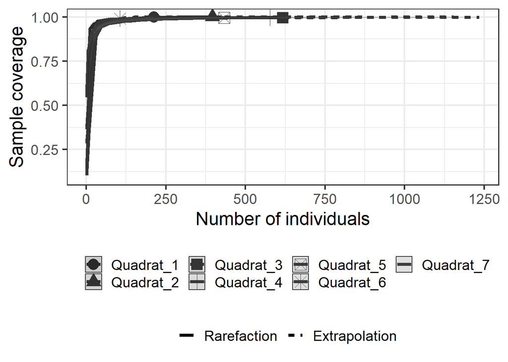

```r
Hodbarrow_Data_Graph3 <- ggiNEXT(x = Hodbarrow_Data, se=TRUE, type = 2,
                                 facet.var= "None", grey=TRUE)
Hodbarrow_Data_Graph3
```

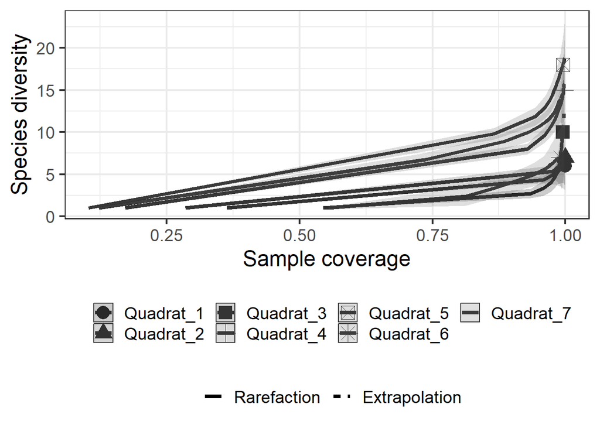

```r
Hodbarrow_Data_Graph4 <- ggiNEXT(x = Hodbarrow_Data, se=TRUE, type = 3,
                                 facet.var= "None", grey=TRUE)
Hodbarrow_Data_Graph4
```

#Warton#

#Loading the Warton data

```r
urlfile2 <- 'https://raw.githubusercontent.com/Savannankvm/Biodiversity-analyses-for-Warton-and-Hodbarrow/PhD-files/Warton_Abundance_Data.csv'

Warton_Nos <-read.csv(urlfile2)

print(Warton_Nos)
```

```
##     Quadrat_1 Quadrat_2 Quadrat_3 Quadrat_4 Quadrat_5 Quadrat_6 Quadrat_7
## 1           0         0         0         0         0         0         0
## 2           0         0         0         0         0         0         0
## 3           0         0         0         0         0         0         0
## 4           0         0         0         0         0        27         0
## 5           0         0         0         0         0         0         0
## 6           0         0         0         0         0         0         0
## 7           0         0         0         0         0         0         0
## 8           0         0         0         0         0         0         0
## 9           1         0         0         0         0         0         0
## 10          0         0         0         0         0         0         0
## 11          0         0         0         0         0        11         0
## 12          0         0        11         0         0        10         0
## 13          0         0         0         0         0         0         0
## 14          0         0         0         0         0         0         0
```

[output cut: 273 more lines]

#colSums to establish sample size for each of the quadrats.

```r
colSums(Warton_Nos)
```

```
## Quadrat_1 Quadrat_2 Quadrat_3 Quadrat_4 Quadrat_5 Quadrat_6 Quadrat_7 Quadrat_8
##       795       568       552       322       517       206       319       343
```

#Setting m to sample size for Quadrat 1. This will give me observed #qD value that will be most representative for Quadrat and Community. Will do the same #for the other communities below.

```r
m <- c(795)

Warton_Datam <- iNEXT(Warton_Nos, q=c(0), datatype= "abundance", size = m)

Warton_Datam
```

```
## Compare 8 assemblages with Hill number order q = 0.
## $class: iNEXT
##
## $DataInfo: basic data information
##   Assemblage   n S.obs     SC f1 f2 f3 f4 f5 f6 f7 f8 f9 f10
## 1  Quadrat_1 795    14 0.9962  3  0  0  0  1  0  0  0  0   0
## 2  Quadrat_2 568     7 0.9965  2  0  0  0  1  0  1  0  0   0
## 3  Quadrat_3 552    12 1.0000  0  1  1  1  1  0  0  1  0   0
## 4  Quadrat_4 322    10 0.9969  1  1  1  0  0  0  0  0  0   0
## 5  Quadrat_5 517    12 0.9961  2  1  0  0  0  1  1  0  0   0
## 6  Quadrat_6 206    13 0.9952  1  1  0  1  1  0  0  0  0   3
## 7  Quadrat_7 319     7 1.0000  1  0  1  0  0  0  0  0  0   0
## 8  Quadrat_8 343     9 1.0000  0  0  0  0  0  0  0  1  0   0
##
## $iNextEst: diversity estimates with rarefied and extrapolated samples.
```

[output cut: 143 more lines]

```r
n <- c(568)

Warton_Datan <- iNEXT(Warton_Nos, q=c(0), datatype= "abundance", size = n)

Warton_Datan
```

```
## Compare 8 assemblages with Hill number order q = 0.
## $class: iNEXT
##
## $DataInfo: basic data information
##   Assemblage   n S.obs     SC f1 f2 f3 f4 f5 f6 f7 f8 f9 f10
## 1  Quadrat_1 795    14 0.9962  3  0  0  0  1  0  0  0  0   0
## 2  Quadrat_2 568     7 0.9965  2  0  0  0  1  0  1  0  0   0
## 3  Quadrat_3 552    12 1.0000  0  1  1  1  1  0  0  1  0   0
## 4  Quadrat_4 322    10 0.9969  1  1  1  0  0  0  0  0  0   0
## 5  Quadrat_5 517    12 0.9961  2  1  0  0  0  1  1  0  0   0
## 6  Quadrat_6 206    13 0.9952  1  1  0  1  1  0  0  0  0   3
## 7  Quadrat_7 319     7 1.0000  1  0  1  0  0  0  0  0  0   0
## 8  Quadrat_8 343     9 1.0000  0  0  0  0  0  0  0  1  0   0
##
## $iNextEst: diversity estimates with rarefied and extrapolated samples.
```

[output cut: 143 more lines]

```r
o <- c(552)

Warton_Datao <- iNEXT(Warton_Nos, q=c(0), datatype= "abundance", size = o)

Warton_Datao
```

```
## Compare 8 assemblages with Hill number order q = 0.
## $class: iNEXT
##
## $DataInfo: basic data information
##   Assemblage   n S.obs     SC f1 f2 f3 f4 f5 f6 f7 f8 f9 f10
## 1  Quadrat_1 795    14 0.9962  3  0  0  0  1  0  0  0  0   0
## 2  Quadrat_2 568     7 0.9965  2  0  0  0  1  0  1  0  0   0
## 3  Quadrat_3 552    12 1.0000  0  1  1  1  1  0  0  1  0   0
## 4  Quadrat_4 322    10 0.9969  1  1  1  0  0  0  0  0  0   0
## 5  Quadrat_5 517    12 0.9961  2  1  0  0  0  1  1  0  0   0
## 6  Quadrat_6 206    13 0.9952  1  1  0  1  1  0  0  0  0   3
## 7  Quadrat_7 319     7 1.0000  1  0  1  0  0  0  0  0  0   0
## 8  Quadrat_8 343     9 1.0000  0  0  0  0  0  0  0  1  0   0
##
## $iNextEst: diversity estimates with rarefied and extrapolated samples.
```

[output cut: 146 more lines]

```r
p <- c(322)

Warton_Datap <- iNEXT(Warton_Nos, q=c(0), datatype= "abundance", size = p)

Warton_Datap
```

```
## Compare 8 assemblages with Hill number order q = 0.
## $class: iNEXT
##
## $DataInfo: basic data information
##   Assemblage   n S.obs     SC f1 f2 f3 f4 f5 f6 f7 f8 f9 f10
## 1  Quadrat_1 795    14 0.9962  3  0  0  0  1  0  0  0  0   0
## 2  Quadrat_2 568     7 0.9965  2  0  0  0  1  0  1  0  0   0
## 3  Quadrat_3 552    12 1.0000  0  1  1  1  1  0  0  1  0   0
## 4  Quadrat_4 322    10 0.9969  1  1  1  0  0  0  0  0  0   0
## 5  Quadrat_5 517    12 0.9961  2  1  0  0  0  1  1  0  0   0
## 6  Quadrat_6 206    13 0.9952  1  1  0  1  1  0  0  0  0   3
## 7  Quadrat_7 319     7 1.0000  1  0  1  0  0  0  0  0  0   0
## 8  Quadrat_8 343     9 1.0000  0  0  0  0  0  0  0  1  0   0
##
## $iNextEst: diversity estimates with rarefied and extrapolated samples.
```

[output cut: 145 more lines]

```r
q <- c(517)

Warton_Dataq <- iNEXT(Warton_Nos, q=c(0), datatype= "abundance", size = q)

Warton_Dataq
```

```
## Compare 8 assemblages with Hill number order q = 0.
## $class: iNEXT
##
## $DataInfo: basic data information
##   Assemblage   n S.obs     SC f1 f2 f3 f4 f5 f6 f7 f8 f9 f10
## 1  Quadrat_1 795    14 0.9962  3  0  0  0  1  0  0  0  0   0
## 2  Quadrat_2 568     7 0.9965  2  0  0  0  1  0  1  0  0   0
## 3  Quadrat_3 552    12 1.0000  0  1  1  1  1  0  0  1  0   0
## 4  Quadrat_4 322    10 0.9969  1  1  1  0  0  0  0  0  0   0
## 5  Quadrat_5 517    12 0.9961  2  1  0  0  0  1  1  0  0   0
## 6  Quadrat_6 206    13 0.9952  1  1  0  1  1  0  0  0  0   3
## 7  Quadrat_7 319     7 1.0000  1  0  1  0  0  0  0  0  0   0
## 8  Quadrat_8 343     9 1.0000  0  0  0  0  0  0  0  1  0   0
##
## $iNextEst: diversity estimates with rarefied and extrapolated samples.
```

[output cut: 144 more lines]

```r
r <- c(206)

Warton_Datar <- iNEXT(Warton_Nos, q=c(0), datatype= "abundance", size = r)

Warton_Datar
```

```
## Compare 8 assemblages with Hill number order q = 0.
## $class: iNEXT
##
## $DataInfo: basic data information
##   Assemblage   n S.obs     SC f1 f2 f3 f4 f5 f6 f7 f8 f9 f10
## 1  Quadrat_1 795    14 0.9962  3  0  0  0  1  0  0  0  0   0
## 2  Quadrat_2 568     7 0.9965  2  0  0  0  1  0  1  0  0   0
## 3  Quadrat_3 552    12 1.0000  0  1  1  1  1  0  0  1  0   0
## 4  Quadrat_4 322    10 0.9969  1  1  1  0  0  0  0  0  0   0
## 5  Quadrat_5 517    12 0.9961  2  1  0  0  0  1  1  0  0   0
## 6  Quadrat_6 206    13 0.9952  1  1  0  1  1  0  0  0  0   3
## 7  Quadrat_7 319     7 1.0000  1  0  1  0  0  0  0  0  0   0
## 8  Quadrat_8 343     9 1.0000  0  0  0  0  0  0  0  1  0   0
##
## $iNextEst: diversity estimates with rarefied and extrapolated samples.
```

[output cut: 146 more lines]

```r
s <- c(319)

Warton_Datas <- iNEXT(Warton_Nos, q=c(0), datatype= "abundance", size = s)

Warton_Datas
```

```
## Compare 8 assemblages with Hill number order q = 0.
## $class: iNEXT
##
## $DataInfo: basic data information
##   Assemblage   n S.obs     SC f1 f2 f3 f4 f5 f6 f7 f8 f9 f10
## 1  Quadrat_1 795    14 0.9962  3  0  0  0  1  0  0  0  0   0
## 2  Quadrat_2 568     7 0.9965  2  0  0  0  1  0  1  0  0   0
## 3  Quadrat_3 552    12 1.0000  0  1  1  1  1  0  0  1  0   0
## 4  Quadrat_4 322    10 0.9969  1  1  1  0  0  0  0  0  0   0
## 5  Quadrat_5 517    12 0.9961  2  1  0  0  0  1  1  0  0   0
## 6  Quadrat_6 206    13 0.9952  1  1  0  1  1  0  0  0  0   3
## 7  Quadrat_7 319     7 1.0000  1  0  1  0  0  0  0  0  0   0
## 8  Quadrat_8 343     9 1.0000  0  0  0  0  0  0  0  1  0   0
##
## $iNextEst: diversity estimates with rarefied and extrapolated samples.
```

[output cut: 147 more lines]

```r
t <- c(343)

Warton_Datat <- iNEXT(Warton_Nos, q=c(0), datatype= "abundance", size = t)

Warton_Datat
```

```
## Compare 8 assemblages with Hill number order q = 0.
## $class: iNEXT
##
## $DataInfo: basic data information
##   Assemblage   n S.obs     SC f1 f2 f3 f4 f5 f6 f7 f8 f9 f10
## 1  Quadrat_1 795    14 0.9962  3  0  0  0  1  0  0  0  0   0
## 2  Quadrat_2 568     7 0.9965  2  0  0  0  1  0  1  0  0   0
## 3  Quadrat_3 552    12 1.0000  0  1  1  1  1  0  0  1  0   0
## 4  Quadrat_4 322    10 0.9969  1  1  1  0  0  0  0  0  0   0
## 5  Quadrat_5 517    12 0.9961  2  1  0  0  0  1  1  0  0   0
## 6  Quadrat_6 206    13 0.9952  1  1  0  1  1  0  0  0  0   3
## 7  Quadrat_7 319     7 1.0000  1  0  1  0  0  0  0  0  0   0
## 8  Quadrat_8 343     9 1.0000  0  0  0  0  0  0  0  1  0   0
##
## $iNextEst: diversity estimates with rarefied and extrapolated samples.
```

[output cut: 147 more lines]

#Now to run the analysis again without specificying the size, can do this for #looking at the other diversity indices

```r
Warton_Data <- iNEXT(Warton_Nos, q=c(0), datatype= "abundance")

print(Warton_Data)
```

```
## Compare 8 assemblages with Hill number order q = 0.
## $class: iNEXT
##
## $DataInfo: basic data information
##   Assemblage   n S.obs     SC f1 f2 f3 f4 f5 f6 f7 f8 f9 f10
## 1  Quadrat_1 795    14 0.9962  3  0  0  0  1  0  0  0  0   0
## 2  Quadrat_2 568     7 0.9965  2  0  0  0  1  0  1  0  0   0
## 3  Quadrat_3 552    12 1.0000  0  1  1  1  1  0  0  1  0   0
## 4  Quadrat_4 322    10 0.9969  1  1  1  0  0  0  0  0  0   0
## 5  Quadrat_5 517    12 0.9961  2  1  0  0  0  1  1  0  0   0
## 6  Quadrat_6 206    13 0.9952  1  1  0  1  1  0  0  0  0   3
## 7  Quadrat_7 319     7 1.0000  1  0  1  0  0  0  0  0  0   0
## 8  Quadrat_8 343     9 1.0000  0  0  0  0  0  0  0  1  0   0
##
## $iNextEst: diversity estimates with rarefied and extrapolated samples.
```

[output cut: 225 more lines]

```r
summary(Warton_Data)
```

```
##          Length Class      Mode
## DataInfo 14     data.frame list
## iNextEst  2     -none-     list
## AsyEst    7     data.frame list
```

#Now to obtain additional biodiversity indices for the Warton data, including sample coverage#

```r
W1 <- diversity(Warton_Nos$Quadrat_1)

Warton2 <- estimateD(Warton_Nos, q = c(0,1,2), datatype = "abundance", base="coverage")
Warton2
```

```
##    Assemblage         m        Method Order.q        SC        qD    qD.LCL
## 1   Quadrat_1 1571.0768 Extrapolation       0 0.9985810 15.868118 12.369665
## 2   Quadrat_1 1571.0768 Extrapolation       1 0.9985810  7.104569  6.629994
## 3   Quadrat_1 1571.0768 Extrapolation       2 0.9985810  5.110373  4.644646
## 4   Quadrat_2  825.1063 Extrapolation       0 0.9985810  7.594533  6.978302
## 5   Quadrat_2  825.1063 Extrapolation       1 0.9985810  3.140309  2.954099
## 6   Quadrat_2  825.1063 Extrapolation       2 0.9985810  2.729852  2.531995
## 7   Quadrat_3  411.3288   Rarefaction       0 0.9985810 11.913994 10.728373
## 8   Quadrat_3  411.3288   Rarefaction       1 0.9985810  5.253358  4.858314
## 9   Quadrat_3  411.3288   Rarefaction       2 0.9985810  3.805113  3.498142
## 10  Quadrat_4  447.1026 Extrapolation       0 0.9985810 10.269278  7.817770
## 11  Quadrat_4  447.1026 Extrapolation       1 0.9985810  5.944195  5.340198
## 12  Quadrat_4  447.1026 Extrapolation       2 0.9985810  4.614480  4.015782
## 13  Quadrat_5 1034.0000 Extrapolation       0 0.9985810 13.262507  9.580330
## 14  Quadrat_5 1034.0000 Extrapolation       1 0.9985810  6.222248  5.769152
```

[output cut: 35 more lines]

```r
Wevenness1 <- W1/log(specnumber(Warton_Nos$Quadrat_1))

summary(Wevenness1)
```

```
##    Min. 1st Qu.  Median    Mean 3rd Qu.    Max.
##  0.7405  0.7405  0.7405  0.7405  0.7405  0.7405
```

```r
W2 <- diversity(Warton_Nos$Quadrat_2)

Wevenness2 <- W2/log(specnumber(Warton_Nos$Quadrat_2))

summary(Wevenness2)
```

```
##    Min. 1st Qu.  Median    Mean 3rd Qu.    Max.
##  0.5867  0.5867  0.5867  0.5867  0.5867  0.5867
```

```r
W3 <- diversity(Warton_Nos$Quadrat_3)

Wevenness3 <- W3/log(specnumber(Warton_Nos$Quadrat_3))

summary(Wevenness3)
```

```
##    Min. 1st Qu.  Median    Mean 3rd Qu.    Max.
##  0.6691  0.6691  0.6691  0.6691  0.6691  0.6691
```

```r
W4 <- diversity(Warton_Nos$Quadrat_4)

Wevenness4 <- W4/log(specnumber(Warton_Nos$Quadrat_4))

summary(Wevenness4)
```

```
##    Min. 1st Qu.  Median    Mean 3rd Qu.    Max.
##  0.7718  0.7718  0.7718  0.7718  0.7718  0.7718
```

```r
W5 <- diversity(Warton_Nos$Quadrat_5)

Wevenness5 <- W5/log(specnumber(Warton_Nos$Quadrat_5))

summary(Wevenness5)
```

```
##    Min. 1st Qu.  Median    Mean 3rd Qu.    Max.
##  0.7324  0.7324  0.7324  0.7324  0.7324  0.7324
```

```r
W6 <- diversity(Warton_Nos$Quadrat_6)

Wevenness6 <- W6/log(specnumber(Warton_Nos$Quadrat_6))

summary(Wevenness6)
```

```
##    Min. 1st Qu.  Median    Mean 3rd Qu.    Max.
##  0.8425  0.8425  0.8425  0.8425  0.8425  0.8425
```

```r
W7 <- diversity(Warton_Nos$Quadrat_7)

Wevenness7 <- W7/log(specnumber(Warton_Nos$Quadrat_7))

summary(Wevenness7)
```

```
##    Min. 1st Qu.  Median    Mean 3rd Qu.    Max.
##  0.8225  0.8225  0.8225  0.8225  0.8225  0.8225
```

```r
W8 <-diversity(Warton_Nos$Quadrat_8)

Wevenness8 <-W8/log(specnumber(Warton_Nos$Quadrat_8))

summary(Wevenness8)
```

```
##    Min. 1st Qu.  Median    Mean 3rd Qu.    Max.
##  0.8356  0.8356  0.8356  0.8356  0.8356  0.8356
```

#Now for Warton data visualisation, including species curve visualisation#

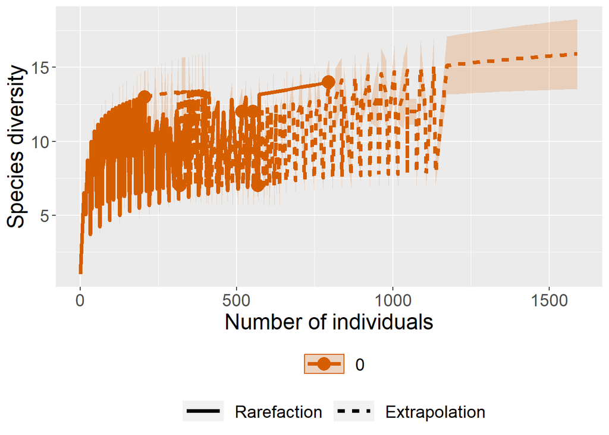

```r
Warton_Data_Graph1 <- ggiNEXT(x = Warton_Data, se=TRUE, color.var="Order.q")

Warton_Data_Graph1
```

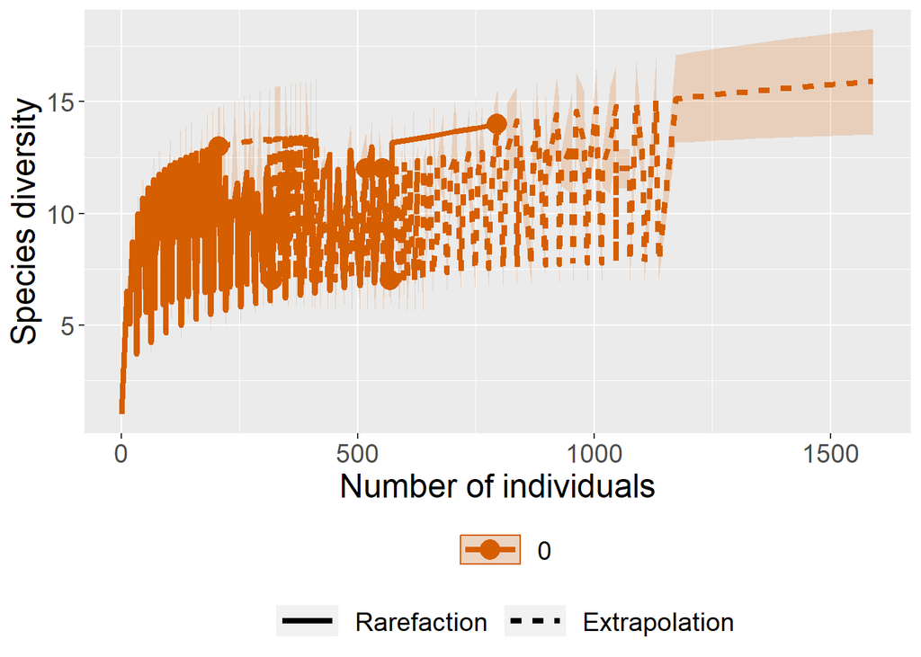

```r
Warton_Data_Graph2 <- ggiNEXT(x = Warton_Data, se=TRUE, type = 1,
                              facet.var="None", color.var="Order.q")

Warton_Data_Graph2
```

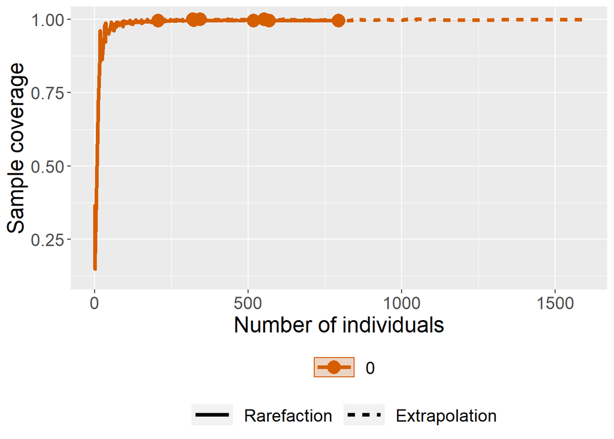

```r
Warton_Data_Graph3 <- ggiNEXT(x = Warton_Data, se=TRUE, type = 2,
                              facet.var="None", color.var="Order.q")

Warton_Data_Graph3
```

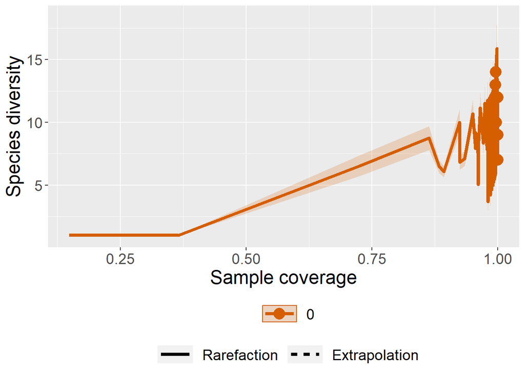

```r
Warton_Data_Graph4 <- ggiNEXT(x = Warton_Data, se=TRUE, type = 3,
                              facet.var="None", color.var="Order.q")

Warton_Data_Graph4
```